# FarmTech Solutions

Sistema de Irrigação Inteligente — Análise Automatizada | Fase 2

Author

Lucas Bohrer

Published

September 28, 2026

# Visão geral

Este relatório apresenta a análise automatizada dos dados registrados pelo protótipo de **Sistema de Irrigação Inteligente desenvolvido para a Fase 2 da FarmTech Solutions**.

Os dados são obtidos diretamente dos arquivos de log gerados durante as simulações do sistema embarcado. A análise é realizada utilizando **R**, permitindo que o relatório seja atualizado automaticamente conforme novos registros são adicionados ao diretório de logs.

**TipAtualização automática**

O relatório não depende de uma quantidade fixa de registros.

Sempre que novos arquivos `.txt` forem adicionados à pasta `logs/`, basta executar novamente o processo de renderização do Quarto para atualizar automaticamente:

- indicadores;
- gráficos;
- estatísticas;
- decisões;
- motivos;
- ciclos de irrigação;
- análise temporal;
- tabelas;
- ciclo mais recente.

# 1 1. Objetivo

O sistema tem como objetivo demonstrar uma estratégia de decisão para irrigação baseada na combinação de múltiplas condições do ambiente simulado.

A lógica considera:

- umidade;
- pH;
- Nitrogênio (N);
- Fósforo (P);
- Potássio (K);
- pontuação multicritério;
- estado dos nutrientes;
- estado da bomba;
- previsão de chuva.

A abordagem busca evitar uma decisão baseada em uma única variável.

A irrigação ocorre quando as condições definidas pela lógica multicritério indicam necessidade e não existe um bloqueio relacionado à previsão meteorológica ou à ausência de nutrientes ativos.

# 2 2. Arquitetura da análise

O fluxo utilizado neste relatório é:

```
ESP32 + Wokwi
      │
      ▼
Arquivos de log (.txt)
      │
      ▼
R / análise dos dados
      │
      ├── Indicadores
      ├── Decisões
      ├── Motivos
      ├── Nutrientes
      ├── Ambiente
      ├── Meteorologia
      └── Ciclos de irrigação
      │
      ▼
Relatório HTML
```

# 3 Processamento automático dos logs

# 4 Indicadores gerais

Os indicadores abaixo são recalculados automaticamente a partir de todos os arquivos `.txt` encontrados na pasta `logs/`.

### Registros

32

logs analisados

### Umidade média

66.6%

umidade simulada

### pH médio

4.7

pH simulado

### Pontuação média

3.94

pontuação multicritério

### Irrigações

7

21.9% dos registros

### Sem irrigação

25

78.1% dos registros

### Bomba ativa

7

registros observados

### Nutrientes

51.9%

média N/P/K

# 5 Decisões de irrigação

## 5.1 Distribuição das decisões

**Mostrar código**

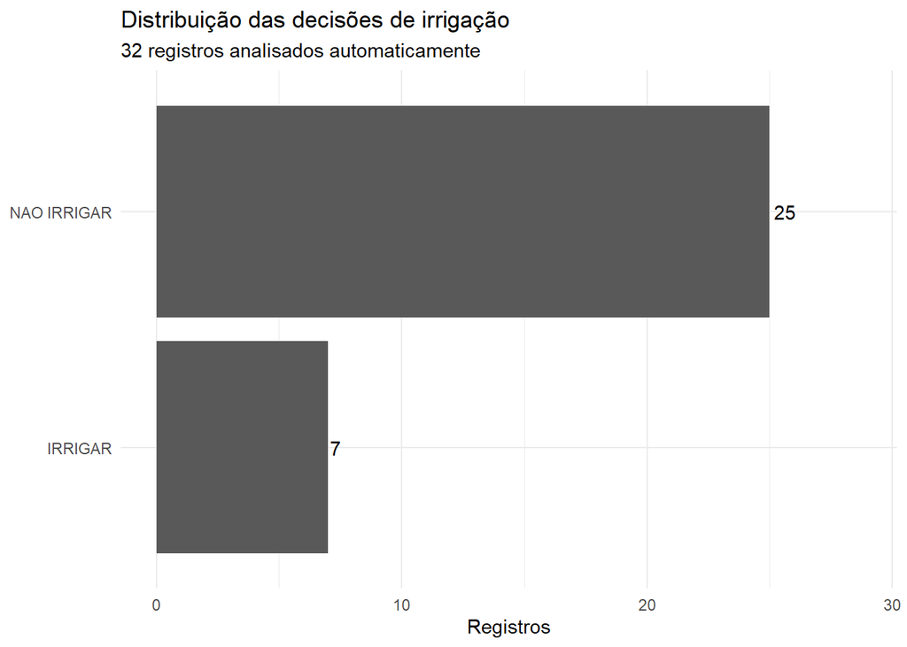

```r
if (nrow(dados) > 0) {
decisoes <- as.data.frame(
  table(
    dados$decisao,
    useNA = "ifany"
  ),
  stringsAsFactors = FALSE
)

colnames(decisoes) <- c(
  "decisao",
  "quantidade"
)

decisoes$decisao <- as.character(
  decisoes$decisao
)

decisoes$decisao[
  is.na(decisoes$decisao)
] <- "Sem decisão registrada"

ggplot(
  decisoes,
  aes(
    x = reorder(decisao, quantidade),
    y = quantidade
  )
) +

  geom_col() +

  geom_text(
    aes(
      label = quantidade
    ),
    hjust = -0.2
  ) +

  coord_flip() +

  labs(
    title = "Distribuição das decisões de irrigação",
    subtitle = paste(
      total_logs,
      "registros analisados automaticamente"
    ),
    x = NULL,
    y = "Registros"
  ) +

  expand_limits(
    y = max(decisoes$quantidade, na.rm = TRUE) * 1.15
  ) +

  theme_minimal()
}
```

**Mostrar código**

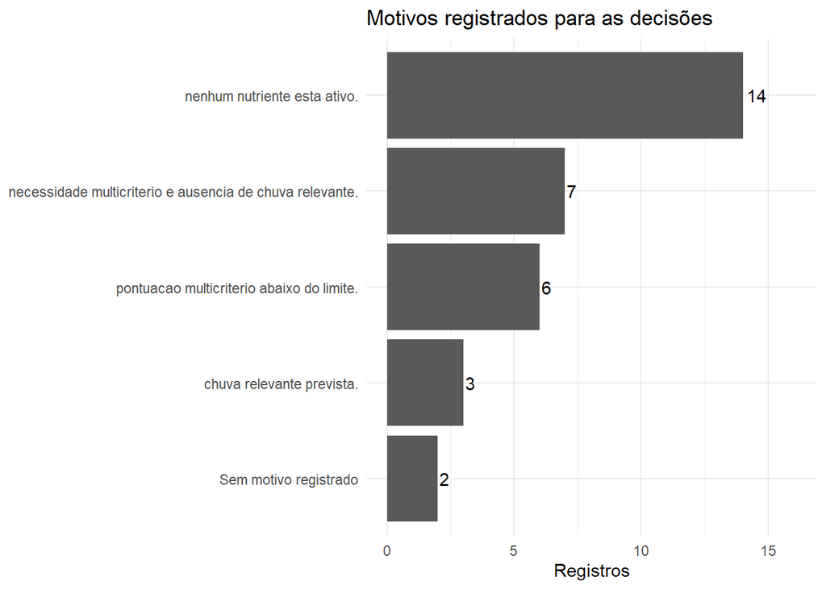

```r
if (nrow(dados) > 0) {
  motivos <- as.data.frame(
  table(
    dados$motivo,
    useNA = "ifany"
  ),
  stringsAsFactors = FALSE
)

colnames(motivos) <- c(
  "motivo",
  "quantidade"
)

motivos$motivo <- as.character(
  motivos$motivo
)

motivos$motivo[
  is.na(motivos$motivo)
] <- "Sem motivo registrado"

ggplot(
  motivos,
  aes(
    x = reorder(motivo, quantidade),
    y = quantidade
  )
) +

  geom_col() +

  geom_text(
    aes(
      label = quantidade
    ),
    hjust = -0.2
  ) +

  coord_flip() +

  labs(
    title = "Motivos registrados para as decisões",
    x = NULL,
    y = "Registros"
  ) +

  expand_limits(
    y = max(motivos$quantidade, na.rm = TRUE) * 1.15
  ) +

  theme_minimal()

}
```

## 5.2 Motivos das decisões

A distribuição dos motivos permite identificar quais regras do sistema mais frequentemente impediram ou permitiram a irrigação.

Isso é importante porque a decisão não depende exclusivamente da pontuação multicritério: a ausência de nutrientes ativos e a previsão de chuva também podem alterar a decisão final.

# 6 Condições ambientais

## 6.1 Umidade simulada

**Mostrar código**

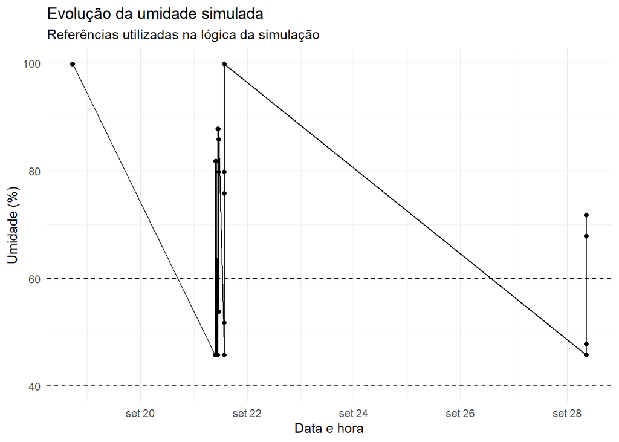

```r
ggplot(
  dados,
  aes(
    x = data_hora,
    y = umidade
  )
) +

  geom_line() +

  geom_point() +

  geom_hline(
    yintercept = 40,
    linetype = "dashed"
  ) +

  geom_hline(
    yintercept = 60,
    linetype = "dashed"
  ) +

  labs(
    title = "Evolução da umidade simulada",
    subtitle = "Referências utilizadas na lógica da simulação",
    x = "Data e hora",
    y = "Umidade (%)"
  ) +

  theme_minimal()
```

Na lógica implementada, valores abaixo de 40% representam maior necessidade hídrica, enquanto valores a partir de 60% deixam de adicionar pontos de necessidade relacionados à umidade.

## 6.2 pH simulado

**Mostrar código**

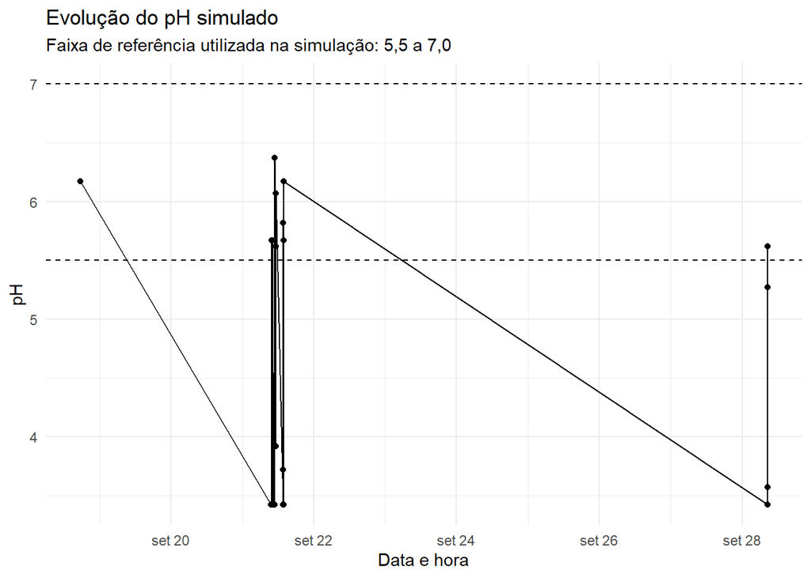

```r
  ggplot(
  dados,
  aes(
    x = data_hora,
    y = ph
  )
) +

  geom_line() +

  geom_point() +

  geom_hline(
    yintercept = 5.5,
    linetype = "dashed"
  ) +

  geom_hline(
    yintercept = 7.0,
    linetype = "dashed"
  ) +

  labs(
    title = "Evolução do pH simulado",
    subtitle = "Faixa de referência utilizada na simulação: 5,5 a 7,0",
    x = "Data e hora",
    y = "pH"
  ) +

  theme_minimal()
```

# 7 Pontuação multicritério

**Mostrar código**

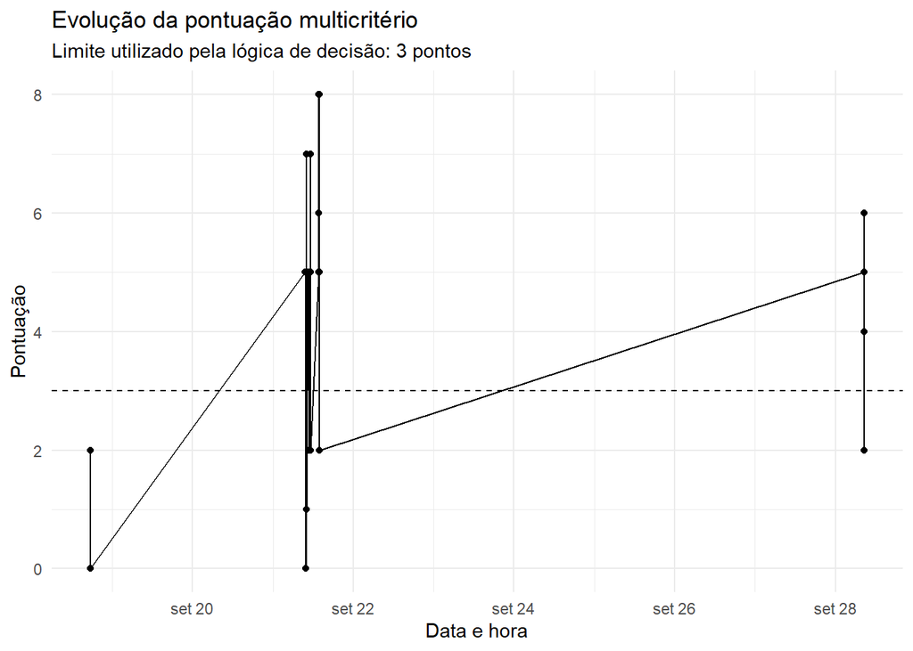

```r
  ggplot(
  dados,
  aes(
    x = data_hora,
    y = pontuacao
  )
) +

  geom_line() +

  geom_point() +

  geom_hline(
    yintercept = 3,
    linetype = "dashed"
  ) +

  labs(
    title = "Evolução da pontuação multicritério",
    subtitle = "Limite utilizado pela lógica de decisão: 3 pontos",
    x = "Data e hora",
    y = "Pontuação"
  ) +

  theme_minimal()
```

A linha tracejada representa o limite de 3 pontos utilizado pela lógica multicritério.

A pontuação não deve ser interpretada isoladamente. A decisão final também considera a existência de nutrientes ativos e os dados meteorológicos disponíveis.

# 8 Níveis de nutrientes

**Mostrar código**

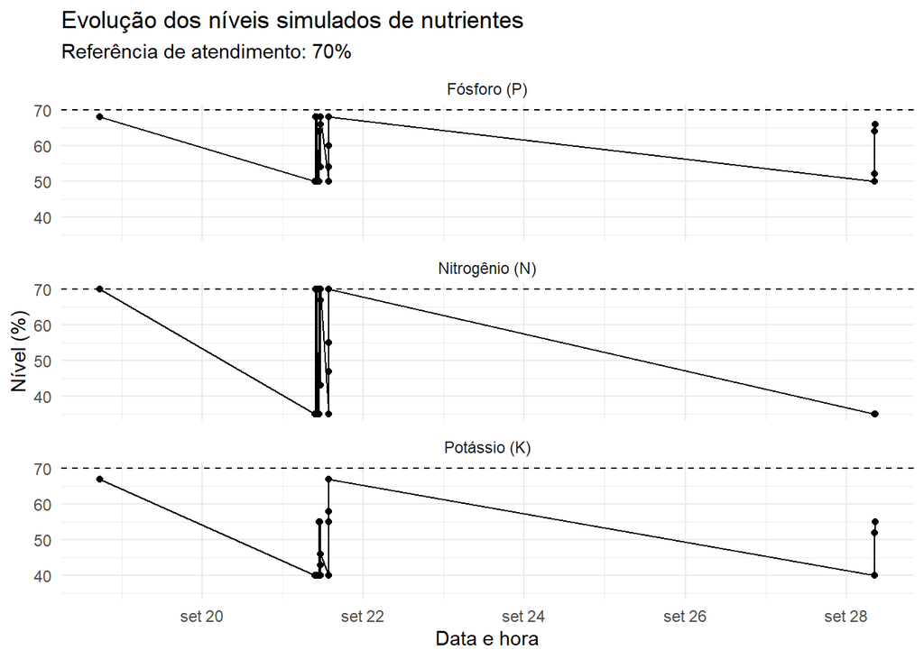

```r
nutrientes <- data.frame(

  data_hora = rep(
    dados$data_hora,
    3
  ),

  nutriente = c(

    rep(
      "Nitrogênio (N)",
      nrow(dados)
    ),

    rep(
      "Fósforo (P)",
      nrow(dados)
    ),

    rep(
      "Potássio (K)",
      nrow(dados)
    )
  ),

  nivel = c(
    dados$nivel_n,
    dados$nivel_p,
    dados$nivel_k
  )
)

ggplot(
  nutrientes,
  aes(
    x = data_hora,
    y = nivel
  )
) +

  geom_line() +

  geom_point() +

  geom_hline(
    yintercept = 70,
    linetype = "dashed"
  ) +

  facet_wrap(
    ~ nutriente,
    ncol = 1
  ) +

  labs(
    title = "Evolução dos níveis simulados de nutrientes",
    subtitle = "Referência de atendimento: 70%",
    x = "Data e hora",
    y = "Nível (%)"
  ) +

  theme_minimal()
```

Na simulação, o nível de 70% é utilizado como referência para considerar o nutriente atendido.

# 9 Integração meteorológica

A integração meteorológica utiliza os dados obtidos pela aplicação Python a partir da previsão meteorológica.

Os registros de precipitação são analisados em diferentes horizontes:

- 3 horas;
- 6 horas;
- 12 horas;
- 24 horas.

**Mostrar código**

```r
meteorologia_disponivel <- any(
  !is.na(dados$chuva_3h) |
  !is.na(dados$chuva_6h) |
  !is.na(dados$chuva_12h) |
  !is.na(dados$chuva_24h)
)
```

**NoteDisponibilidade dos dados**

Não foram encontrados dados meteorológicos registrados nos logs atuais.

**Mostrar código**

```r
if (meteorologia_disponivel) {

  chuva <- data.frame(

    data_hora = dados$data_hora,

    `3 horas` = dados$chuva_3h,

    `6 horas` = dados$chuva_6h,

    `12 horas` = dados$chuva_12h,

    `24 horas` = dados$chuva_24h
  )

  chuva_longa <- chuva |>

    pivot_longer(
      cols = -data_hora,
      names_to = "horizonte",
      values_to = "milimetros"
    )

  ggplot(
    chuva_longa,
    aes(
      x = data_hora,
      y = milimetros,
      group = horizonte
    )
  ) +

    geom_line() +

    geom_point() +

    labs(
      title = "Precipitação prevista registrada",
      x = "Data e hora",
      y = "Precipitação prevista (mm)",
      color = "Horizonte"
    ) +

    theme_minimal()
}
```

A previsão meteorológica funciona como uma camada adicional da tomada de decisão. Quando existe chuva relevante prevista, o sistema pode impedir a irrigação mesmo que os demais critérios indiquem necessidade.

# 10 Análise dos ciclos de irrigação

Para analisar a dinâmica da bomba, os registros são percorridos cronologicamente.

Um ciclo é identificado quando ocorre:

`INATIVA → ATIVA → INATIVA`

Essa abordagem permite que o relatório continue funcionando quando novos ciclos forem registrados.

**Mostrar código**

```r
dados$estado_bomba_anterior <- dplyr::lag(
  dados$bomba
)

inicio_indices <- which(
  dados$bomba == "ATIVA" &
    (
      is.na(dados$estado_bomba_anterior) |
      dados$estado_bomba_anterior != "ATIVA"
    )
)

ciclos <- list()

if (length(inicio_indices) > 0) {

  for (inicio_idx in inicio_indices) {

    fim_indices <- which(
      seq_len(nrow(dados)) > inicio_idx &
        dados$bomba == "INATIVA"
    )

    if (length(fim_indices) > 0) {

      fim_idx <- fim_indices[1]

      inicio <- dados[inicio_idx, ]
      fim <- dados[fim_idx, ]

      ciclos[[length(ciclos) + 1]] <- data.frame(

        inicio = inicio$data_hora,

        fim = fim$data_hora,

        janela_segundos = as.numeric(
          difftime(
            fim$data_hora,
            inicio$data_hora,
            units = "secs"
          )
        ),

        umidade_inicio = inicio$umidade,

        umidade_fim = fim$umidade,

        variacao_umidade =
          fim$umidade -
          inicio$umidade,

        ph_inicio = inicio$ph,

        ph_fim = fim$ph,

        variacao_ph =
          fim$ph -
          inicio$ph,

        n_inicio = inicio$nivel_n,

        n_fim = fim$nivel_n,

        p_inicio = inicio$nivel_p,

        p_fim = fim$nivel_p,

        k_inicio = inicio$nivel_k,

        k_fim = fim$nivel_k,

        pontuacao_inicio =
          inicio$pontuacao,

        pontuacao_fim =
          fim$pontuacao,

        decisao_final =
          fim$decisao,

        stringsAsFactors = FALSE
      )
    }
  }
}

if (length(ciclos) > 0) {

  ciclos_df <- do.call(
    rbind,
    ciclos
  )

} else {

  ciclos_df <- data.frame()
}
```

### 10.0.1 10.1 Resumo dos ciclos

**Mostrar código**

```r
numero_ciclos <- nrow(ciclos_df)

if (numero_ciclos > 0) {

  ciclos_resumo <- ciclos_df |>
    mutate(
      inicio = format(
        inicio,
        "%d/%m/%Y %H:%M:%S"
      ),

      fim = format(
        fim,
        "%d/%m/%Y %H:%M:%S"
      ),

      janela_segundos =
        round(janela_segundos, 0)
    ) |>

    mutate(Ciclo = row_number()) |>

    select(
      Ciclo,
      `Início` = inicio,
      `Fim` = fim,
      `Janela observada (s)` =
        janela_segundos,
      `Umidade inicial (%)` =
        umidade_inicio,
      `Umidade final (%)` =
        umidade_fim,
      `Variação umidade (p.p.)` =
        variacao_umidade,
      `pH inicial` =
        ph_inicio,
      `pH final` =
        ph_fim,
      `Variação pH` =
        variacao_ph,
      `N final (%)` =
        n_fim,
      `P final (%)` =
        p_fim,
      `K final (%)` =
        k_fim
    )

  ciclos_resumo
}
```

```
  Ciclo              Início                 Fim Janela observada (s)
1     1 21/09/2026 11:16:36 21/09/2026 11:17:08                   32
2     2 21/09/2026 13:45:13 21/09/2026 13:46:09                   56
3     3 21/09/2026 13:47:14 21/09/2026 13:47:30                   16
4     4 28/09/2026 08:34:52 28/09/2026 08:35:23                   31
  Umidade inicial (%) Umidade final (%) Variação umidade (p.p.) pH inicial
1                53.8              85.8                      32       3.92
2                51.8              45.8                      -6       3.72
3                75.8              99.8                      24       5.67
4                47.8              71.8                      24       3.57
  pH final Variação pH N final (%) P final (%) K final (%)
1     6.07        2.15          70          68          46
2     3.42       -0.30          35          50          40
3     6.17        0.50          70          68          67
4     5.62        2.05          35          66          55
```

**ImportantObservação sobre a duração**

A janela observada representa o intervalo entre o primeiro log com a bomba ATIVA e o primeiro log posterior com a bomba INATIVA.

Como os logs são capturados em intervalos discretos, esse valor não representa necessariamente o tempo físico exato em que o relé permaneceu acionado. Ele representa o intervalo observado pela coleta de logs.

# 11 Ciclo mais recente

**Mostrar código**

```r
if (numero_ciclos > 0) {

  ultimo_ciclo <- ciclos_df[
    nrow(ciclos_df),
  ]

} else {

  ultimo_ciclo <- NULL
}
```

**TipResultado do ciclo mais recente**

Foram identificados 4 ciclo(s) completo(s) nos registros analisados.

**Mostrar código**

```r
if (numero_ciclos > 0) {

  cat(
    "Início observado: ",
    format(
      ultimo_ciclo$inicio,
      "%d/%m/%Y %H:%M:%S"
    ),
    "\n\n",
    sep = ""
  )

  cat(
    "Fim observado: ",
    format(
      ultimo_ciclo$fim,
      "%d/%m/%Y %H:%M:%S"
    ),
    "\n\n",
    sep = ""
  )

  cat(
    "Janela observada: ",
    ultimo_ciclo$janela_segundos,
    " segundos",
    "\n\n",
    sep = ""
  )
}
```

```
Início observado: 28/09/2026 08:34:52

Fim observado: 28/09/2026 08:35:23

Janela observada: 31 segundos
```

### 11.0.1 11.1 Evolução durante o ciclo mais recente

**Mostrar código**

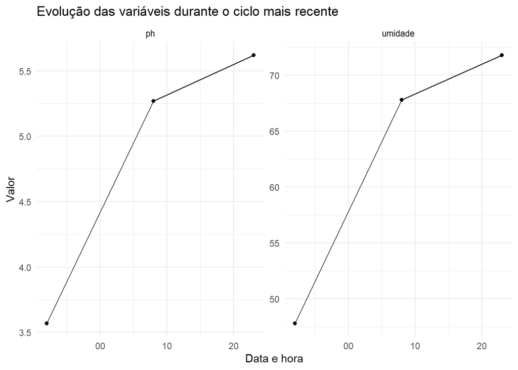

```r
if (numero_ciclos > 0) {

  inicio_ciclo <- which(
    dados$data_hora ==
      ultimo_ciclo$inicio
  )[1]

  fim_ciclo <- which(
    dados$data_hora ==
      ultimo_ciclo$fim
  )[1]

  dados_ciclo <- dados[
    inicio_ciclo:fim_ciclo,
  ]

  dados_ciclo_long <- dados_ciclo |>

    select(
      data_hora,
      umidade,
      ph
    ) |>

    pivot_longer(
      cols = c(
        umidade,
        ph
      ),
      names_to = "variavel",
      values_to = "valor"
    )

  ggplot(
    dados_ciclo_long,
    aes(
      x = data_hora,
      y = valor
    )
  ) +

    geom_line() +

    geom_point() +

    facet_wrap(
      ~ variavel,
      scales = "free_y"
    ) +

    labs(
      title = "Evolução das variáveis durante o ciclo mais recente",
      x = "Data e hora",
      y = "Valor"
    ) +

    theme_minimal()
}
```

### 11.0.2 11.2 Comparação inicial e final

**Mostrar código**

```r
if (numero_ciclos > 0) {

  tabela_ciclo <- data.frame(

    Variável = c(
      "Umidade simulada",
      "pH simulado",
      "Nitrogênio (N)",
      "Fósforo (P)",
      "Potássio (K)",
      "Pontuação"
    ),

    Início = c(
      ultimo_ciclo$umidade_inicio,
      ultimo_ciclo$ph_inicio,
      ultimo_ciclo$n_inicio,
      ultimo_ciclo$p_inicio,
      ultimo_ciclo$k_inicio,
      ultimo_ciclo$pontuacao_inicio
    ),

    Final = c(
      ultimo_ciclo$umidade_fim,
      ultimo_ciclo$ph_fim,
      ultimo_ciclo$n_fim,
      ultimo_ciclo$p_fim,
      ultimo_ciclo$k_fim,
      ultimo_ciclo$pontuacao_fim
    )
  )

  tabela_ciclo$Variação <- round(
    tabela_ciclo$Final -
      tabela_ciclo$Início,
    2
  )

  tabela_ciclo
}
```

```
          Variável Início Final Variação
1 Umidade simulada  47.80 71.80    24.00
2      pH simulado   3.57  5.62     2.05
3   Nitrogênio (N)  35.00 35.00     0.00
4      Fósforo (P)  52.00 66.00    14.00
5     Potássio (K)  40.00 55.00    15.00
6        Pontuação   6.00  2.00    -4.00
```

No conjunto atual de dados, o ciclo observado demonstra a evolução da simulação desde uma condição inicial de maior necessidade até uma condição na qual a pontuação multicritério deixa de atingir o limite de irrigação.

# 12 Estado da bomba

**Mostrar código**

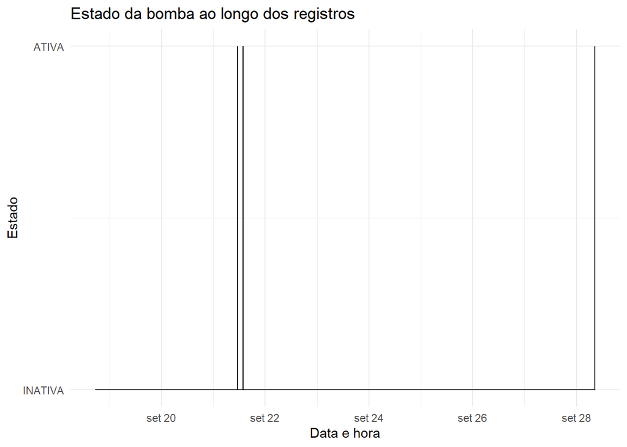

```r
ggplot(
  dados,
  aes(
    x = data_hora,
    y = ifelse(
      bomba == "ATIVA",
      1,
      0
    )
  )
) +

  geom_step() +

  scale_y_continuous(
    breaks = c(
      0,
      1
    ),
    labels = c(
      "INATIVA",
      "ATIVA"
    )
  ) +

  labs(
    title = "Estado da bomba ao longo dos registros",
    x = "Data e hora",
    y = "Estado"
  ) +

  theme_minimal()
```

# 13 Resumo automático dos motivos

**Mostrar código**

```r
motivos_resumo <- dados |>

  mutate(
    motivo = ifelse(
      is.na(motivo),
      "Sem motivo registrado",
      motivo
    )
  ) |>

  count(
    motivo,
    name = "registros"
  ) |>

  arrange(
    desc(registros)
  )

motivos_resumo
```

```
                                                    motivo registros
1                             nenhum nutriente esta ativo.        14
2 necessidade multicriterio e ausencia de chuva relevante.         7
3                pontuacao multicriterio abaixo do limite.         6
4                                chuva relevante prevista.         3
5                                    Sem motivo registrado         2
```

# 14 Dados completos

A tabela abaixo apresenta os registros utilizados na análise.

**Mostrar código**

```r
dados_tabela <- dados

dados_tabela$data_hora <- format(
  dados_tabela$data_hora,
  "%d/%m/%Y %H:%M:%S"
)

dados_tabela
```

```
                   arquivo           data_hora   bomba umidade   ph pontuacao
1  2026-09-18_17-24-12.txt 18/09/2026 17:24:12 INATIVA    99.8 6.17         2
2  2026-09-18_17-25-13.txt 18/09/2026 17:25:13 INATIVA    99.8 6.17         2
3  2026-09-18_17-26-16.txt 18/09/2026 17:26:16 INATIVA    99.8 6.17         0
4  2026-09-18_17-27-17.txt 18/09/2026 17:27:17 INATIVA    99.8 6.17         0
5  2026-09-21_09-36-46.txt 21/09/2026 09:36:46 INATIVA    45.8 3.42         5
6  2026-09-21_09-37-49.txt 21/09/2026 09:37:49 INATIVA    45.8 3.42         5
7  2026-09-21_09-51-22.txt 21/09/2026 09:51:22 INATIVA    81.8 5.67         0
8  2026-09-21_09-52-25.txt 21/09/2026 09:52:25 INATIVA    81.8 5.67         0
9  2026-09-21_09-56-04.txt 21/09/2026 09:56:04 INATIVA    45.8 3.42         7
10 2026-09-21_09-57-53.txt 21/09/2026 09:57:53 INATIVA    45.8 3.42         5
11 2026-09-21_09-58-53.txt 21/09/2026 09:58:53 INATIVA    81.8 5.67         1
12 2026-09-21_10-23-23.txt 21/09/2026 10:23:23 INATIVA    45.8 3.42         5
13 2026-09-21_10-52-19.txt 21/09/2026 10:52:19 INATIVA    45.8 3.42         5
14 2026-09-21_10-53-22.txt 21/09/2026 10:53:22 INATIVA    45.8 3.42         5
```

[output cut: 117 more lines]

# 15 Conclusão

A análise automatizada demonstra que o sistema de irrigação inteligente utiliza múltiplas variáveis para apoiar a decisão de acionamento da bomba.

Os registros permitem acompanhar simultaneamente:

- condições de umidade;
- pH simulado;
- níveis de N, P e K;
- pontuação multicritério;
- decisões de irrigação;
- motivos das decisões;
- estado da bomba;
- previsão de precipitação; e
- evolução dos ciclos de irrigação.

A estrutura implementada em R permite que a análise seja escalável para novos registros. Dessa forma, novos arquivos adicionados ao diretório `logs/` são incorporados automaticamente na próxima renderização do relatório.

No conjunto atual de dados, foram analisados 32 registros, sendo identificados 7 registros com decisão de irrigação e 25 registros sem irrigação.

O relatório também identificou automaticamente 4 ciclo(s) completo(s) de irrigação.

**Note**

Limitações da simulação

Os valores de umidade e pH utilizados pelo sistema representam variáveis simuladas para demonstrar o funcionamento da lógica de decisão.

Da mesma forma, os efeitos da irrigação sobre as variáveis ambientais e os níveis de nutrientes são parâmetros definidos para a simulação e não devem ser interpretados como um modelo agronômico real.

A integração meteorológica também depende da previsão fornecida pela API utilizada e está sujeita às limitações inerentes às previsões meteorológicas.

Portanto, os resultados demonstram o funcionamento técnico da arquitetura e da lógica de decisão proposta, não constituindo uma validação agronômica para uso em campo.

# 16 Reprodutibilidade

Para gerar este relatório novamente, mantenha o arquivo `relatorio.qmd` na pasta `R/` e os logs na pasta `logs/` do projeto. Todo arquivo `.txt` novo será lido automaticamente na próxima renderização.

```powershell
& "C:\Users\Lucas\AppData\Local\Programs\Quarto\bin\quarto.exe" render "R/relatorio.qmd"
```